# Exploratory Text Analysis

Fabiano Andrade Lima

March 20, 2016

# Introduction

Our goal in this paper is to understand and explore the data from a corpus called HC Corpora (www.corpora.heliohost.org) that that will be the used as base for creating a model to predict a word given one, two or three words.

First of all, we will be working with three files, as it follows:

```r
setwd("/Users/fabianoal/Documents/GitHub/Data Science Capstone Project")

cname <- paste0(getwd(),"/final/en_US")
files <- paste(cname, list.files(cname), sep="/")
filesTbl <- as.data.frame(files)

filesTbl$size <- sapply(files, function(x) file.size(x), simplify = "array")

sample_size = 0.1
set.seed(345)
corpusVector <- vector(mode = 'character')
lengths <- vector(mode = 'numeric')
for (j in files){
  f <- file(j)
  lines <- readLines(f)
  lengths <- append(lengths, length(lines))
  s <- sample(length(lines), size = trunc(length(lines)*sample_size), replace=FALSE)
  corpusVector <- append(corpusVector, lines[s])
  close(f)
}

filesTbl$files <- gsub(paste0(cname, "/"),"",filesTbl$files)
filesTbl$lines <- lengths

kable(filesTbl)
```

| files | size | lines |
| --- | --- | --- |
| en_US.blogs.txt | 210160014 | 899288 |
| en_US.news.txt | 205811889 | 1010242 |
| en_US.twitter.txt | 167105338 | 2360148 |

# The contents

In the previous step, we took advantage of the the file reading and sampled 10% of its contents to work with (426,967 documents) so it will make possible to get a little bit of insight about the contents of the three files.

Now, we use the quanteda library to create a corpus so we can check features and some other statistics about our dataset.

```r
mCorpus <- quanteda::corpus(corpusVector)
#dfm function takes care of removing ponctuations and numbers. It also applies "tolower" by default
unigrams <- dfm(mCorpus, removeNumbers = TRUE, removePunct = TRUE, removeSeparators = TRUE, removeTwitter = TRUE)
#now we create a vector with all features ordered by frequency (desc)
tfUnigrams <- topfeatures(unigrams, n = ncol(unigrams))
#then we create a data.frame so we can use it with ggplot2
tfUnigrams <- as.data.frame(tfUnigrams)
tfUnigrams$x <- 1:nrow(tfUnigrams)
colnames(tfUnigrams) <- c("Frequency", "x")

#this function is used to return how many unique features responds to a given % of all features
gramsForCoverage <- function(grams, cName, thres){
  totalTerms <- sum(grams[,c(cName)])
  uniqueTerms <- 0
  for (j in 1:nrow(grams)){
    uniqueTerms <- uniqueTerms + 1
    if (sum(grams[1:uniqueTerms, c(cName)]) >= (totalTerms * thres)){
      break
    }
  }
  uniqueTerms
}
```

From our sample, we have a total of 9,986,730 words. This means that the entire dataset should have about 99,867,300 words total.

Besides, with only 142 unique words we cover 50% of the entire sample.

This is due, in part, to the fact that in our pre-processing, we kept prepositions, articles and other, but it was on purpose. Our final goal is to create a model to predict next words based on the past one, two and three words, and in this case, those terms matters.

The frequency distribution can be better understood in the plot below. The vertical line shows the number of words necessary to cover 50% of the entire sample.

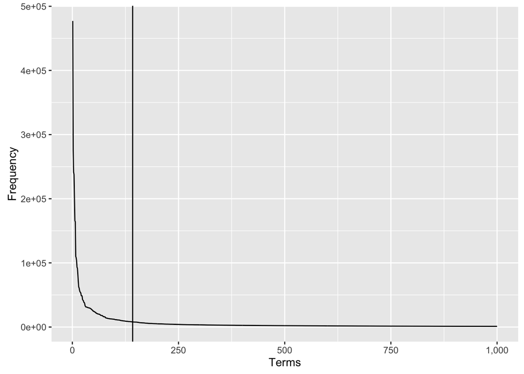

```r
g <- ggplot(tfUnigrams[1:1000,], aes(x, Frequency))
g <- g + geom_line()
g <- g + geom_vline(aes(xintercept = gramsForCoverage(tfUnigrams, "Frequency", 0.5)))
g <- g + xlab("Terms")
g <- g + scale_x_continuous(labels = comma)
g
```

Now, to get a idea of what are these terms that respondes for 50% of the entire corpus, lets check the wordcloud below:

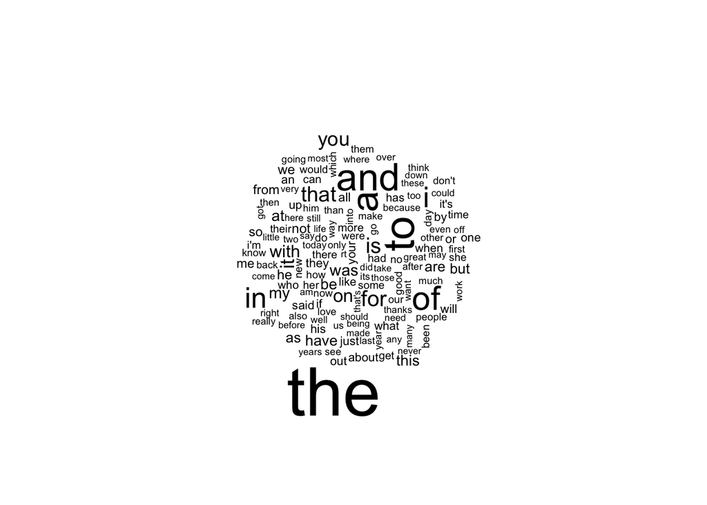

```r
topFeatures <- as.data.frame(topfeatures(unigrams, n=gramsForCoverage(tfUnigrams, "Frequency", 0.5)))
colnames(topFeatures) <- c("freq")

wordcloud(words = rownames(topFeatures), freq=topFeatures$freq)
```